# Depression Detection on Reddit: An NLP Approach

Sneha Mariam Thomas

#### **Introduction**

In recent years, online platforms, particularly social media, have played an increasingly significant role in shaping mental health discourse and providing avenues for self-expression and support. Reddit, as one of the largest online communities, stands out for its diverse discussions, including those related to mental health.  
Reddit provides an anonymous environment that enables users to share their experiences and seek support without the fear of judgment. This anonymity is particularly important for those dealing with mental health issues, as it can reduce the stigma associated with discussing personal struggles. On Reddit, individuals can find both information and emotional support, contributing to a more open and inclusive dialogue about mental health.

Accurately detecting mental health concerns on Reddit is crucial for several reasons. The platform’s anonymity encourages users to share their true feelings and experiences, providing valuable insights into the mental health issues people face. This candidness helps in understanding these challenges more deeply and empathetically. Moreover, mental illness often carries stigma, which can prevent individuals from seeking help through traditional avenues. Reddit allows users to discuss their struggles in a less stigmatized environment, underscoring the need for effective methods to detect and address these issues. Early detection of mental health concerns can lead to timely support and intervention, offering resources or guidance to individuals who may not have sought help otherwise. Identifying mental health issues on Reddit can also facilitate the delivery of targeted support and resources, such as professional help, supportive communities, or educational content about mental health.

Detecting mental health concerns on Reddit comes with challenges. Users may describe their mental health experiences in diverse ways, making it difficult to standardize detection methods. Accurate detection also requires understanding the context in which mental health issues are discussed, which can be complex due to the diverse nature of discussions and user interactions. Balancing effective detection with respect for user privacy is crucial, as interventions must be handled delicately to avoid breaching the confidentiality that users value.

This project aims to detect depression in Reddit posts through a combination of text analysis and machine learning methodologies. Initially, the text data is preprocessed to remove noise and standardize the input, followed by the application of Term Frequency-Inverse Document Frequency (TF-IDF) analysis to highlight distinctive words and phrases associated with depression. Various classification algorithms, including Naive Bayes with unigram and bigram analysis, Ridge regression, and Lasso regression, are evaluated to determine their effectiveness in classifying posts as indicative of depression or not. The goal is to enhance the accuracy of depression detection in online discourse, facilitating more timely and targeted interventions based on linguistic patterns. This approach not only improves the classification process but also offers deeper insights into the linguistic features of depression-related discussions on Reddit.

#### **Data**

The dataset utilized for this project is sourced from Kaggle and is titled “Depression: Reddit Dataset (Cleaned).” It encompasses 7,731 Reddit posts that have been annotated based on whether the authors have been diagnosed with depression.These posts were made accessible after a cleaning process, which involved converting all text to lowercase and removing punctuation marks. Labels were obtained by querying individuals about their depression diagnosis, followed by collecting messages from these individuals. The dataset exhibits a split of 3,900 instances, representing subreddits of individuals diagnosed with depression, and 3,831 instances, indicating individuals without a depression diagnosis.The dataset can be accessed [here](https://www.kaggle.com/datasets/infamouscoder/depression-reddit-cleaned/data).

#### **Research Question**

**a. In what ways do the words used in posts by individuals with depression diverge from those in posts by individuals without depression?**

**b. How well does the classification model, utilizing linguistic features, differentiate between Reddit posts authored by individuals with depression and those by individuals without depression?**

#### **a. Word Analysis**

A basic comparison of top words featured in posts by depressed and non-depressed individuals offers a preliminary glimpse into the distinct linguistic patterns associated with different mental health states, providing initial clues for further exploration and analysis.

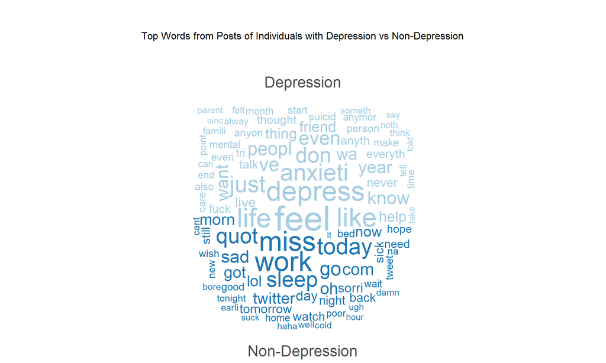

While observing top words in posts provides insights into the most commonly used words in each category but may overlook the significance of less frequent but more meaningful terms. It lacks the ability to identify unique linguistic markers or themes specific to each category.

Employing **Term Frequency-Inverse Document Frequency** (TF-IDF) captures nuanced language distinctions, offering deeper understanding and context-specific relevance. TF-IDF highlights words distinctive to each group, filtering out common terms to reveal meaningful insights. Analyzing TF-IDF scores can uncover prevalent themes and topics within each group’s discourse, shedding light on differences in communication patterns and issues of significance. This comparative analysis not only helps identify unique linguistic markers but also provides valuable context for understanding the distinct experiences and perspectives expressed by individuals with depression versus those without.

Top Words from Posts by People with Depression and Non-Depression (Ranked by TF-IDF Scores)

| Depression | Non-Depression |
| --- | --- |
| therapi | twitpic |
| relationship | awww |
| medic | boo |
| disord | argh |
| diagnos | kal |
| chest | kutner |
| experienc | penn |
| apart | plurk |
| covid | cantu |
| human | stephenkruis |
| trauma | itun |
| grade | ouch |
| truli | hahaha |
| whenev | mac |
| trigger | heidimontag |
| cope | jonathanrknight |
| failur | dvd |
| overwhelm | yawn |
| father | earthquak |
| partner | mileycyrus |

Examining the top words based on TF-IDF scores offers a nuanced glimpse into the language dynamics of individuals with depression compared to those without. In posts associated with depression, terms like “therapy,” “relationship,” and “medication” surface prominently, suggesting a focus on seeking help, navigating interpersonal challenges, and managing mental health treatments. These words reflect a deeper engagement with emotional struggles and coping mechanisms inherent in depression discourse. Conversely, the non-depression category showcases terms such as “twitpic,” “awww,” and “boo,” indicating a lighter conversational tone and a range of topics unrelated to mental health. This contrast underscores the divergent linguistic landscapes between the two groups, with depression-related discussions delving into personal hardships and psychological well-being, while non-depression discussions span various everyday subjects.

However, relying solely on TF-IDF analysis of Reddit posts from individuals with depression and non-depression for mental health classification can be misleading due to the nuanced and multifaceted nature of language, as well as the intricate manifestations of mental health conditions. While TF-IDF captures word importance within individual documents, it may overlook contextual nuances, individualized experiences, and diverse expressions inherent in mental health discussions. Therefore, employing a more sophisticated approach, such as classification algorithms, becomes imperative. These algorithms can incorporate a broader spectrum of features beyond TF-IDF (like ngrams), enabling a more nuanced and comprehensive understanding of mental health states based on online language use.

#### **b. Building Classification Algorithm**

**b.1 Methodology**  
Preliminarily, Naive Bayes was chosen as the classifier for text classification due to its efficiency in managing large feature spaces and deriving predictions from observed feature likelihoods. Shifting from unigram to bigram analysis, the latter facilitated the capture of contextual dependencies between adjacent words, thereby enriching the model’s comprehension of language nuances and bolstering classification accuracy.

Alternatively, regularization techniques were applied to bigrams to address overfitting concerns and enhance the model’s generalization capability. By regulating coefficient magnitudes and reducing model complexity, these methods bolster the model’s capacity to accurately classify whether a post indicates that the post owner has depression or not.

**b.2 Comparison and Selection of Classification Algorithms**

Accuracy provides an overall assessment of the classifier’s performance, indicating the proportion of correctly classified instances out of all instances. While high accuracy is desirable, it may not be the sole determining factor when dealing with a sensitive issue like depression. Some of the other factors for consideration are:

- **Precision** focuses on the accuracy of positive predictions, indicating the proportion of correctly identified depressed individuals among all people classified having depression.
- **Recall** measures the ability of the classifier to capture all instances of depression among all depressed individuals. A higher recall score indicates that the classifier is effective in identifying individuals with depression. In the context of this classification, a high recall score ensures that fewer cases of depression go undetected, enabling timely interventions and support for affected individuals.
- **F1 score** balances precision and recall, providing a harmonic mean that reflects the overall performance of the classifier.A higher F1 score indicates a better balance between accurately identifying depressed individuals (precision) and capturing all instances of depression (recall).
- **Negative Predictive Value** measures the accuracy of negative predictions, indicating the proportion of correctly identified non-depressed individuals among all instances classified as negative. In this case, a high NPV ensures that individuals who are not depressed are correctly identified, reducing the likelihood of unnecessary interventions.

Model Evaluation Metrics

| Metric | Unigram:Naive Bayes | Bigram: Naive Bayes | Ridge:Bigram | Lasso:Bigram |
| --- | --- | --- | --- | --- |
| Accuracy | 0.8603749 | 0.8661926 | 0.8319328 | 0.9385908 |
| Precision | 0.8116740 | 0.8016789 | 1.0000000 | 0.9942446 |
| Recall | 0.9424552 | 0.9769821 | 0.6675192 | 0.8836317 |
| F1 Score | 0.8721893 | 0.8806916 | 0.8006135 | 0.9356804 |
| Negative Predictive Value | 0.9295775 | 0.9696970 | 0.7463415 | 0.8931925 |

Positive Class-1 (Diagnosed with Depression)

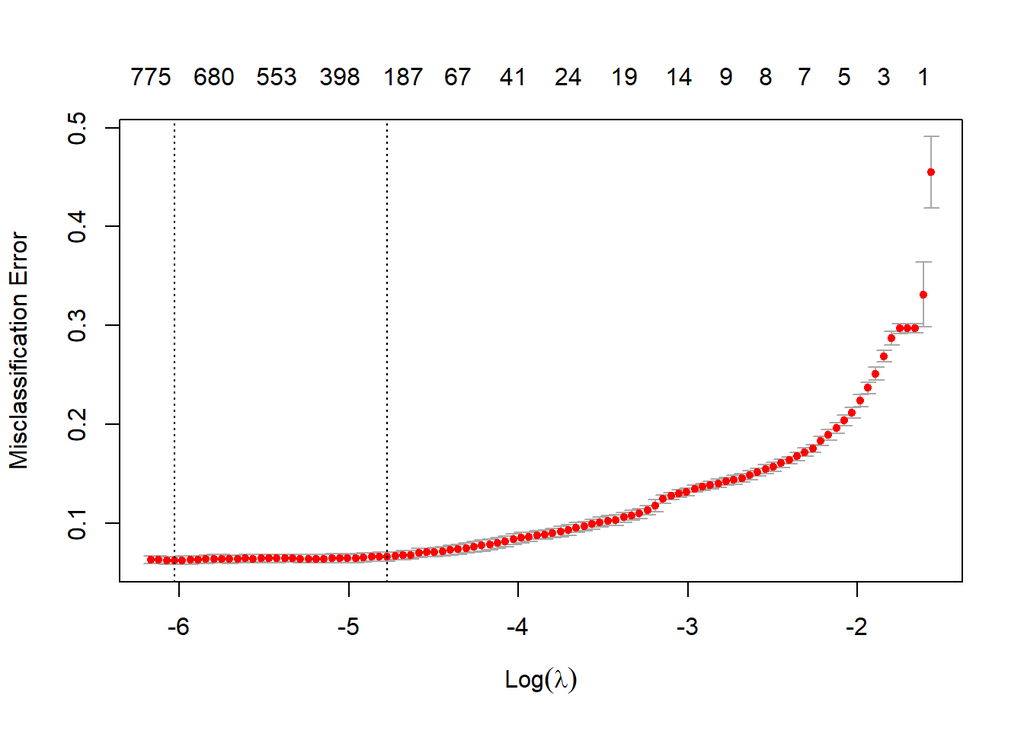

Top Predictive Words for Depression Detection

| depress | pression | dont_bother | work_wish | final_decid | finit | anxieti | comment_re | friend_hope | mg_everi |
| --- | --- | --- | --- | --- | --- | --- | --- | --- | --- |
| around_everyon | enough_school | tonight_goodby | hel | best_good | therapi_medit | one_awhil | pathet_lazi | someon_talk | pretti_low |
| fuck_littl | anyon | job_fire | titl | pain_hate | dead_ive | basic_task | opposit_sex | idk_edit | ask_well |

Overall, these words provide insight into how personal experiences of depression are influenced by social interactions, life challenges, and cultural contexts, offering a comprehensive understanding of mental health from multiple perspectives.

#### **Appendix: Code**

```r
# this chunk generates the complete code appendix.
# eval=FALSE tells R not to run (``evaluate'') the code here (it was already run before).
knitr::opts_chunk$set(echo = FALSE, warning = FALSE, message = FALSE, cache = TRUE, fig.align="center")
library("quanteda", quietly = TRUE, warn.conflicts = FALSE, verbose = FALSE)
library("quanteda.textmodels")
library(quanteda)
library(readr)
library(tidyverse)
library(tm)
library(quanteda.textplots)
library(quanteda.textstats)
library(gridExtra)
library(caret)
library(pROC)
library(glmnet)
library(knitr)
library(ggplot2)
library(kableExtra)
require(doMC)
library(htmltools)
data <- read.csv("C:/Users/sneha/OneDrive/Desktop/PROJECT/data/depression_dataset_reddit_cleaned.csv",stringsAsFactors = F)
dep_corpus <- corpus(data$clean_text)

# Cleaned text and punctuations are removed, and all text is in lowercase
dep_tokens <- tokens(dep_corpus, remove_numbers = TRUE, remove_symbols = TRUE,remove_url = TRUE)

# Remove custom stopwords and perform word stemming
dep_tokens <- tokens_remove(dep_tokens, stopwords("en"))
dep_tokens <- tokens_remove(dep_tokens, pattern = c("http", "amp","tinyurl"))
#Single occuring alphabets
dep_tokens <- tokens_select(dep_tokens, min_nchar = 2)
dep_tokens <- tokens_wordstem(dep_tokens)

dep_dfm <- dfm(dep_tokens)
#Assigning Doc Labels
is_depression <- grepl("1", data$is_depression)
doc_labels <- ifelse(is_depression, "Depression", "Non-Depression")
dep_dfm_grouped <- dfm_group(dep_dfm, groups = doc_labels)

layout(matrix(c(1, 2), nrow=2), heights=c(1, 4))
par(mar=rep(0, 4))
plot.new()
text(x=0.5, y=0.5, "Top Words from Posts of Individuals with Depression vs Non-Depression")
textplot_wordcloud(dep_dfm_grouped, comparison = TRUE,main="Title",max_words = 100)


dp_tfidf <- dfm_tfidf(dep_dfm_grouped)
top_words <- topfeatures(dp_tfidf, n = 20, groups = docnames(dep_dfm_grouped))

top_words_table <- data.frame(Depression = names(top_words$Depression),Non_Depression =names(top_words$`Non-Depression`))

title <- "Top Words from Posts by People with Depression and Non-Depression <br> (Ranked by TF-IDF Scores)"

top_words_table %>%
  kable("html", align = "c", caption = title, col.names = c("Depression", "Non-Depression")) %>%
  kable_styling(full_width = 50)%>% column_spec(c(1:2), border_left = TRUE, border_right = TRUE)%>%
  row_spec(nrow(top_words_table), extra_css = "border-bottom: 1px solid black;")


set.seed(123)
train_index <- sample(1:nrow(dep_dfm), 0.8 * nrow(dep_dfm))
train_dfm <- dep_dfm[train_index, ]
test_dfm <- dep_dfm[-train_index, ]
train_labels <- data$is_depression[train_index]
test_labels <-  data$is_depression[-train_index]
set.seed(123)
nb_classifier_uni <- textmodel_nb(train_dfm, y = train_labels)
predictions_uni <- predict(nb_classifier_uni, newdata = test_dfm)
prob_uni <- predict(nb_classifier_uni, newdata = test_dfm, type = "prob")
conf_matrix_uni <- confusionMatrix(predictions_uni, as.factor(test_labels), positive="1")#Depression

accuracy_uni <- (conf_matrix_uni$overall["Accuracy"])
precision_uni <- (conf_matrix_uni$byClass["Pos Pred Value"])
recall_uni <- (conf_matrix_uni$byClass["Sensitivity"])
f1_score_uni <- (2*precision_uni*recall_uni)/sum(precision_uni,recall_uni)
neg_pred_uni <- (conf_matrix_uni$byClass["Neg Pred Value"])

metric_names_uni <- c("Accuracy", "Precision", "Recall", "F1 Score","Negative Predictive Value")
metric_values_uni <- c(accuracy_uni, precision_uni, recall_uni, f1_score_uni,neg_pred_uni)
metrics_df_uni <- data.frame(Metric = metric_names_uni,Value = metric_values_uni)
rownames(metrics_df_uni) <- NULL


#BIGRAMS

dep_tokens_bi <- tokens_ngrams(dep_tokens,n=1:2)
dep_dfm_bi <- dfm(dep_tokens_bi)
dep_dfm_bi <- dfm_trim(dep_dfm_bi, min_docfreq = 2)
train_dfm_bi <- dep_dfm_bi[train_index, ]
test_dfm_bi<- dep_dfm_bi[-train_index, ]
train_labels_bi <- data$is_depression[train_index]
test_labels_bi <-  data$is_depression[-train_index]
set.seed(123)
nb_classifier_bi <- textmodel_nb(train_dfm_bi, y = train_labels_bi)
predictions_bi <- predict(nb_classifier_bi, newdata = test_dfm_bi)
conf_matrix_bi <- confusionMatrix(predictions_bi, as.factor(test_labels_bi), positive="1")

accuracy_bi <- (conf_matrix_bi$overall["Accuracy"])
precision_bi <- (conf_matrix_bi$byClass["Pos Pred Value"])
recall_bi <- (conf_matrix_bi$byClass["Sensitivity"])
f1_score_bi <- (2*precision_bi*recall_bi)/sum(precision_bi,recall_bi)
neg_pred_bi <- (conf_matrix_bi$byClass["Neg Pred Value"])

metric_names_bi <- c("Accuracy", "Precision", "Recall", "F1 Score","Negative Predictive Value")
metric_values_bi <- c(accuracy_bi, precision_bi, recall_bi, f1_score_bi,neg_pred_bi)
metrics_df_bi <- data.frame(Metric = metric_names_bi,Value = metric_values_bi)
rownames(metrics_df_bi) <- NULL


#RIDGE REGRESSION

registerDoMC(cores=3)
set.seed(123)
ridge <- cv.glmnet(train_dfm_bi,train_labels_bi,family="binomial", alpha=0, nfolds=5, parallel=TRUE, intercept=TRUE,type.measure="class")
best.lambda.ridge <- which(ridge$lambda==ridge$lambda.1se)
preds_ridge <- predict(ridge, test_dfm_bi, type="class",lambda=best.lambda.ridge)
#ridge_prob <- predict(ridge, test_dfm_bi, type = "response",lambda=best.lambda.ridge)
conf_matrix_ridge <- confusionMatrix(as.factor(preds_ridge), as.factor(test_labels_bi),positive="1")

accuracy_ridge <- (conf_matrix_ridge$overall["Accuracy"])
precision_ridge <- (conf_matrix_ridge$byClass["Pos Pred Value"])
recall_ridge <- (conf_matrix_ridge$byClass["Sensitivity"])
f1_score_ridge <- (2*precision_ridge*recall_ridge)/sum(precision_ridge,recall_ridge)
neg_pred_ridge <- (conf_matrix_ridge$byClass["Neg Pred Value"])

metric_names_ridge <- c("Accuracy", "Precision", "Recall", "F1 Score","Negative Predictive Value")
metric_values_ridge <- c(accuracy_ridge, precision_ridge, recall_ridge, f1_score_ridge,neg_pred_ridge)
metrics_df_ridge  <- data.frame(Metric = metric_names_ridge ,Value = metric_values_ridge )
rownames(metrics_df_ridge ) <- NULL

#LASSO

set.seed(123)
lasso <- cv.glmnet(train_dfm_bi,train_labels_bi,family="binomial", alpha=1, nfolds=5, parallel=TRUE, intercept=TRUE,type.measure="class")
best.lambda.lasso <- which(lasso$lambda==lasso$lambda.1se)
preds_lasso <- predict(lasso, test_dfm_bi, type="class",lambda=best.lambda.lasso )

conf_matrix_lasso <- confusionMatrix(as.factor(preds_lasso), as.factor(test_labels_bi),positive="1")

accuracy_lasso <- (conf_matrix_lasso$overall["Accuracy"])
precision_lasso <- (conf_matrix_lasso$byClass["Pos Pred Value"])
recall_lasso <- (conf_matrix_lasso$byClass["Sensitivity"])
f1_score_lasso <- (2*precision_lasso*recall_lasso)/sum(precision_lasso,recall_lasso)
neg_pred_lasso <- (conf_matrix_lasso$byClass["Neg Pred Value"])

metric_names_lasso <- c("Accuracy", "Precision", "Recall", "F1 Score","Negative Predictive Value")
metric_values_lasso <- c(accuracy_lasso, precision_lasso, recall_lasso, f1_score_lasso,neg_pred_lasso)
metrics_df_lasso  <- data.frame(Metric = metric_names_lasso ,Value = metric_values_lasso )
rownames(metrics_df_lasso ) <- NULL

comparison_df <- cbind(metrics_df_uni, metrics_df_bi[, 2], metrics_df_ridge[, 2], metrics_df_lasso[, 2])
colnames(comparison_df) <- c("Metric", "Unigram:Naive Bayes", "Bigram: Naive Bayes","Ridge:Bigram","Lasso:Bigram")


comparison_table <- kable(comparison_df, align = "c", format = "html",
                          caption = "Model Evaluation Metrics") %>%add_footnote("Positive Class-1 (Diagnosed with Depression)",notation="none") %>% kable_styling(full_width = 100)%>%column_spec(c(1:5), border_left = TRUE, border_right = TRUE)%>%
  row_spec(nrow(comparison_df), extra_css = "border-bottom: 1px solid black;")

comparison_table
plot(lasso)

beta <- lasso$glmnet.fit$beta[,best.lambda.lasso]

# Create a dataframe with only the words
df <- data.frame(word = names(beta),
                 coef = as.numeric(beta),
                 stringsAsFactors = FALSE)

# Order the dataframe by coefficients in descending order
df <- df[order(df$coef, decreasing = TRUE), ]

# Reset row names for clarity
rownames(df) <- 1:nrow(df)

# Extract the top 30 words
top_30_words <- head(df[, "word"], n = 30)

# Reshape the top 30 words into a matrix with 3 rows and 10 columns
top_words_matrix <- matrix(top_30_words, nrow = 3, byrow = TRUE)

# Convert the matrix to a dataframe for easy display
top_words_df <- as.data.frame(top_words_matrix)

# Display the table without column names
library(knitr)
library(kableExtra)

kable(top_words_df,
      col.names = NULL, # Remove column names
      caption = "Top Predictive Words for Depression Detection",
      format = "html") %>%
  kable_styling(full_width = TRUE,
                position = "center")%>%column_spec(c(1:10), border_left = TRUE, border_right = TRUE)%>%
  row_spec(nrow(top_words_df), extra_css = "border-bottom: 1px solid black;")


# this chunk generates the complete code appendix.
# eval=FALSE tells R not to run (``evaluate'') the code here (it was already run before).
```